# Eléments de statistique descriptive avec R

Mohamad Ghassany

30/03/2018

# Données quantitatives discrètes

Le nombre d’arbres plantés sur les parcelles d’un lotissement a été compté. Les données obtenues sont les suivantes:

$$1,2,4,1,6,3,2,1,2,0,1,2,2,1,3,0,3,2,1,2,2,3,2,3.$$

1. Quelle est la nature de variable étudiée?
2. Rentrer ces données sous la forme d’un vecteur nommé `arbres` et affichez ce vecteur.

```r
arbres = c(1,2,4,1,6,3,2,1,2,0,1,2,2,1,3,0,3,2,1,2,2,3,2,3)
arbres
```

```
##  [1] 1 2 4 1 6 3 2 1 2 0 1 2 2 1 3 0 3 2 1 2 2 3 2 3
```

3. Trier les valeurs de ce vecteur par ordre croissant.

```r
sort(arbres) # en ordre croissant
```

```
##  [1] 0 0 1 1 1 1 1 1 2 2 2 2 2 2 2 2 2 3 3 3 3 3 4 6
```

```r
sort(arbres,decreasing = T) # en ordre décroissant
```

```
##  [1] 6 4 3 3 3 3 3 2 2 2 2 2 2 2 2 2 1 1 1 1 1 1 0 0
```

4. Donner la taille de l’échantillon (c’est-à-dire le nombre de composantes de ce vecteur) en la notant `n` et affichez sa valeur.

```r
n = length(arbres)
n
```

```
## [1] 24
```

## Effectifs et fréquence

5. Montrer la séquence des modalités et la séquence des effectifs correspondants.

```r
sort(unique(arbres)) # les modalités
```

```
## [1] 0 1 2 3 4 6
```

```r
effectifs = table(arbres) # pour calculer les effectifs
effectifs
```

```
## arbres
## 0 1 2 3 4 6
## 2 6 9 5 1 1
```

6. Montrer le tableau de fréquences et de pourcentages.

```r
frequences = effectifs/n
frequences
```

```
## arbres
##          0          1          2          3          4          6
## 0.08333333 0.25000000 0.37500000 0.20833333 0.04166667 0.04166667
```

```r
pourcentages = frequences * 100 # ou (effectifs*100)/n
pourcentages
```

```
## arbres
##         0         1         2         3         4         6
##  8.333333 25.000000 37.500000 20.833333  4.166667  4.166667
```

7. Calculer et afficher les effectifs cumulés et les fréquences cumulées.

```r
effectifs_cumules = cumsum(effectifs)
effectifs_cumules
```

```
##  0  1  2  3  4  6
##  2  8 17 22 23 24
```

```r
frequences_cumulees = cumsum(frequences)
frequences_cumulees
```

```
##          0          1          2          3          4          6
## 0.08333333 0.33333333 0.70833333 0.91666667 0.95833333 1.00000000
```

## Mesures de tendance centrale

8. Calculer le nombre moyen d’arbres par parcelle.

```r
moyenne = mean(arbres)
moyenne
```

```
## [1] 2.041667
```

9. Calculer le nombre maximum et le nombre minimum d’arbres sur une parcelle.

```r
max(arbres)
```

```
## [1] 6
```

```r
min(arbres)
```

```
## [1] 0
```

10. Calculer le nombre médian d’arbres par parcelle.

```r
mediane = median(arbres)
mediane
```

```
## [1] 2
```

11. Utiliser la fonction `summary()` pour obtenir un tableau récapitulatif des indicateurs.

```r
summary(arbres)
```

```
##    Min. 1st Qu.  Median    Mean 3rd Qu.    Max.
##   0.000   1.000   2.000   2.042   3.000   6.000
```

## Indicateurs de dispersion

12. Calculer la variance et l’écart-type du nombre d’arbres plantés sur les parcelles.

```r
var(arbres)
```

```
## [1] 1.693841
```

13. Calculer maintenant l’écart-type et vérifier que l’écart-type est la racine carrée de la variance.

```r
ecart_type = sd(arbres)
ecart_type
```

```
## [1] 1.301476
```

```r
ecart_type^2
```

```
## [1] 1.693841
```

14. Calculer la variance vous-même. La variance obtenue est elle la même que la précédente?

```r
variance =  sum((arbres-mean(arbres))^2)/length(arbres)
variance
```

```
## [1] 1.623264
```

```r
# la fonction var() calcule la variance corrigée
```

Le logiciel `R` utilise *n* − 1 pour le dénomiateur dans la définition de la variance, c’est-à-dire $\frac{1}{n-1} \sum_{i=1}^n (x_i - \bar{x})^2$ (d’écart-type noté *σ*<sub>*n* − 1</sub> ou *s*. Cette quantité est souvent préférée dans les applications numériques pour des questions d’estimation).

## Représentations graphiques

15. La fontion `plot()` affiche par défaut un nuage de points avec en abscisse le numéro de l’observation (ici de 1 à 24) et en ordonnée le nombre d’arbres. Tester cette fonction. Modifier le titre de la figure, les noms des axes, la couleur et la forme des points affichés.

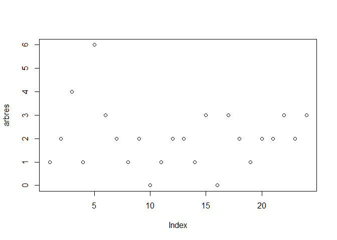

```r
plot(arbres)
```

16. Afficher la courbe des fréquence cumulées. (**Indication**: Utiliser la fonction `ecdf()`).

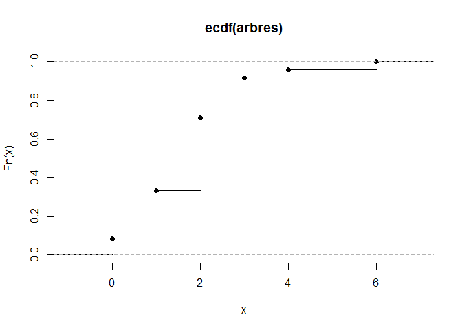

```r
plot(ecdf(arbres))
```

17. Tracer un diagramme en bâtons par la fonction `barplot()` à partir du tableau des effectifs ou des fréquences.

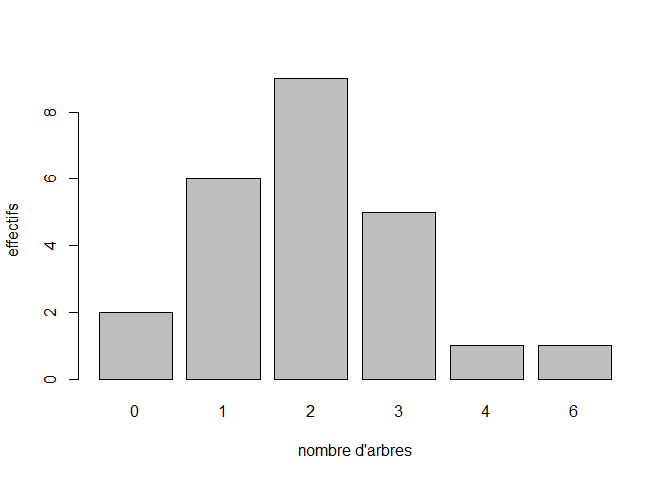

```r
barplot(effectifs, xlab="nombre d'arbres", ylab="effectifs")
```

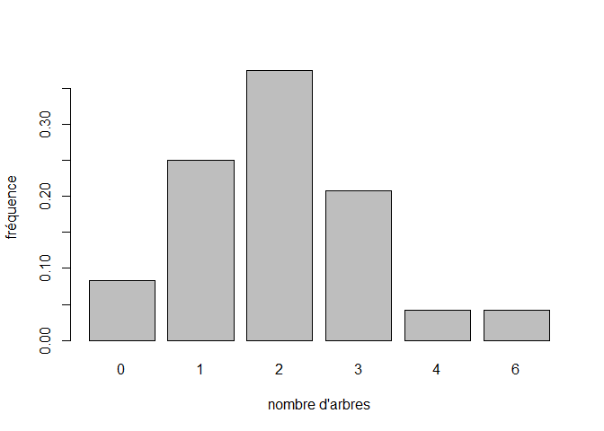

```r
barplot(frequences, xlab="nombre d'arbres", ylab="fréquence")
```